# Logistic regression

## Chapter description

The following chapter analyses alcohol consumption of students of two Portuguese schools. The data attributes include student grades, demographic, social and school related features, and it was collected by using school reports and questionnaires. The variables’ names can be found below and their detailed description [here](https://archive.ics.uci.edu/ml/datasets/Student+Performance).The purpose of current analysis is to study the relationships between high/low alcohol consumption and some of the other variables in the data.

```r
alc <- read.csv("/Users/anastasia/IODS-project/data/alc.csv")
dim(alc)
```

```
## [1] 382  35
```

```r
colnames(alc)
```

```
##  [1] "school"     "sex"        "age"        "address"    "famsize"
##  [6] "Pstatus"    "Medu"       "Fedu"       "Mjob"       "Fjob"
## [11] "reason"     "nursery"    "internet"   "guardian"   "traveltime"
## [16] "studytime"  "failures"   "schoolsup"  "famsup"     "paid"
## [21] "activities" "higher"     "romantic"   "famrel"     "freetime"
## [26] "goout"      "Dalc"       "Walc"       "health"     "absences"
## [31] "G1"         "G2"         "G3"         "alc_use"    "high_use"
```

```r
str(alc)
```

```
## 'data.frame':    382 obs. of  35 variables:
##  $ school    : Factor w/ 2 levels "GP","MS": 1 1 1 1 1 1 1 1 1 1 ...
##  $ sex       : Factor w/ 2 levels "F","M": 1 1 1 1 1 2 2 1 2 2 ...
##  $ age       : int  18 17 15 15 16 16 16 17 15 15 ...
##  $ address   : Factor w/ 2 levels "R","U": 2 2 2 2 2 2 2 2 2 2 ...
##  $ famsize   : Factor w/ 2 levels "GT3","LE3": 1 1 2 1 1 2 2 1 2 1 ...
##  $ Pstatus   : Factor w/ 2 levels "A","T": 1 2 2 2 2 2 2 1 1 2 ...
##  $ Medu      : int  4 1 1 4 3 4 2 4 3 3 ...
##  $ Fedu      : int  4 1 1 2 3 3 2 4 2 4 ...
##  $ Mjob      : Factor w/ 5 levels "at_home","health",..: 1 1 1 2 3 4 3 3 4 3 ...
##  $ Fjob      : Factor w/ 5 levels "at_home","health",..: 5 3 3 4 3 3 3 5 3 3 ...
##  $ reason    : Factor w/ 4 levels "course","home",..: 1 1 3 2 2 4 2 2 2 2 ...
##  $ nursery   : Factor w/ 2 levels "no","yes": 2 1 2 2 2 2 2 2 2 2 ...
##  $ internet  : Factor w/ 2 levels "no","yes": 1 2 2 2 1 2 2 1 2 2 ...
##  $ guardian  : Factor w/ 3 levels "father","mother",..: 2 1 2 2 1 2 2 2 2 2 ...
```

[output cut: 21 more lines]

## Exploratory data analysis

For selecting some interesting variables for future analysis it’s helpful to first visualize them.

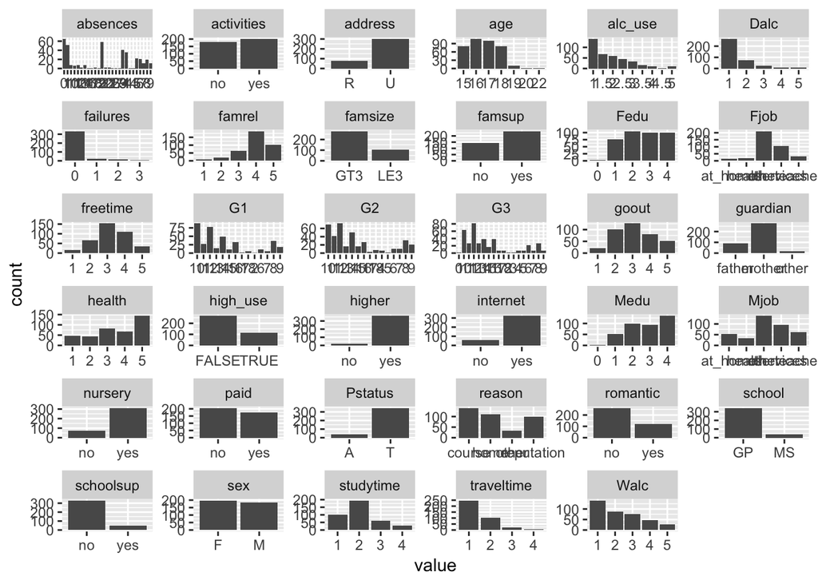

```r
library(corrr)
alc %>% select_if(is.numeric) %>% correlate() %>% focus(alc_use, Dalc, Walc)
```

```
##
## Correlation method: 'pearson'
## Missing treated using: 'pairwise.complete.obs'
```

```
## # A tibble: 14 x 4
##    rowname     alc_use    Dalc     Walc
##    <chr>         <dbl>   <dbl>    <dbl>
##  1 age         0.162    0.134   0.157
##  2 Medu        0.00924  0.0454 -0.0173
##  3 Fedu        0.00859  0.0215 -0.00168
##  4 traveltime  0.163    0.160   0.140
##  5 studytime  -0.246   -0.186  -0.251
##  6 failures    0.185    0.162   0.174
##  7 famrel     -0.121   -0.0930 -0.122
##  8 freetime    0.178    0.197   0.138
##  9 goout       0.387    0.268   0.411
## 10 health      0.0779   0.0625  0.0768
## 11 absences    0.215    0.174   0.210
## 12 G1         -0.176   -0.169  -0.155
## 13 G2         -0.159   -0.151  -0.140
## 14 G3         -0.156   -0.159  -0.131
```

## Hypothesis testing

Based on computed correlation coefficients and my personal reasoning I come up with the **following hypothesis**:

1. Male schoolers consume more alcohol that female (sex)
2. Alcohol consumption decreases grades (in fact it’s three variables: G1, G2, G3)
3. Alcohol consumption increases number of school absences (absences)
4. Going out with friends increases alcohol consumption (goout)

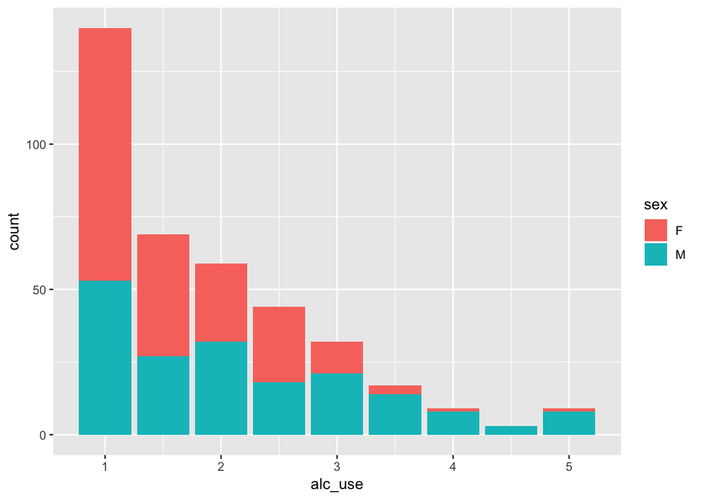

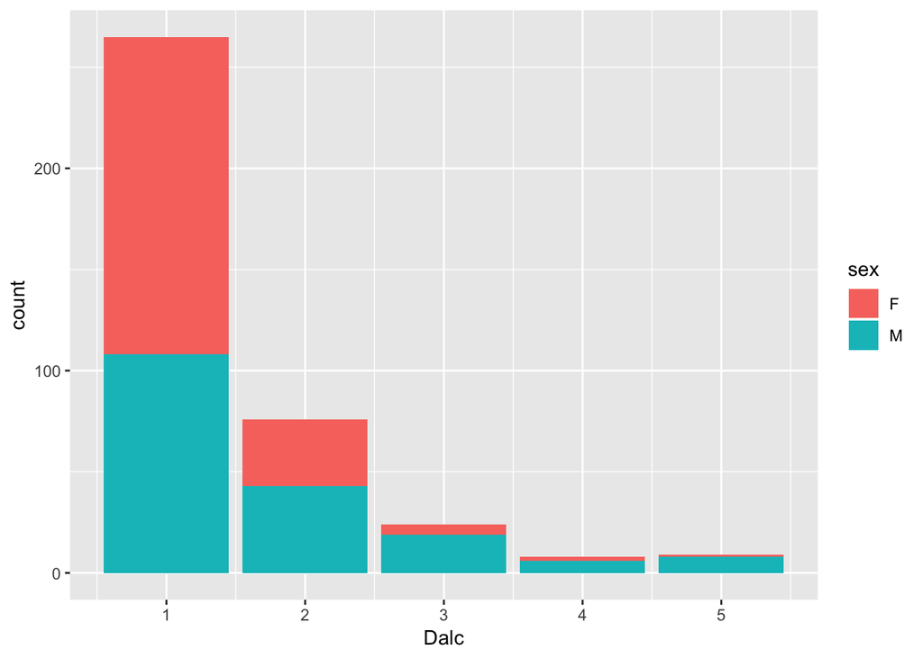

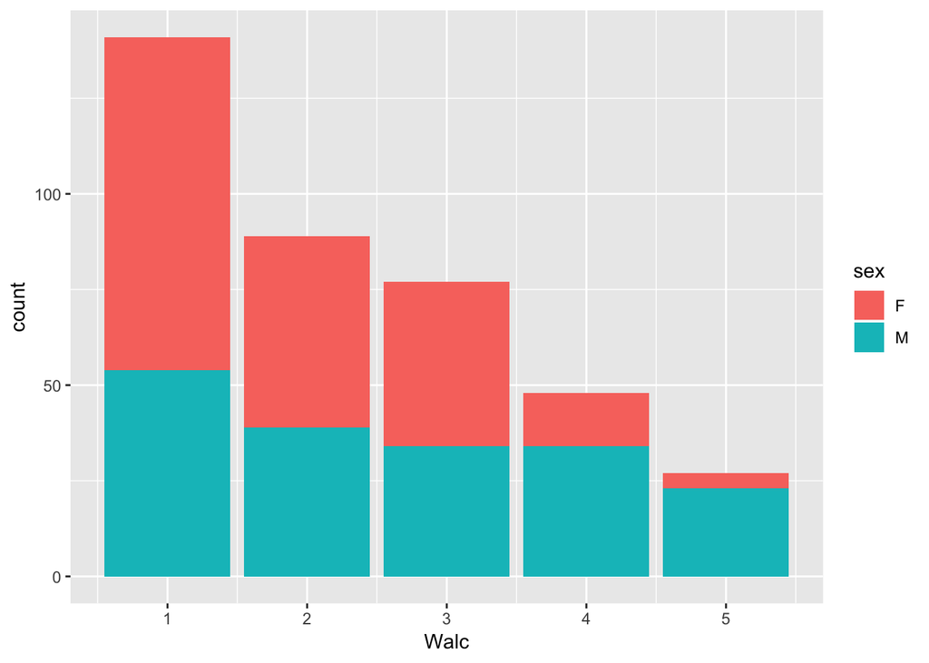

Next we explore relationship between alcohol use and grades. First, I compute mean grade (average of G1, G2, G3).

```r
alc$G <- (alc$G1 + alc$G2 + alc$G3)/3
```

Now I plot the relationship. The overall trend supports my hypothesis about negative relationship between alcohol use and grades.

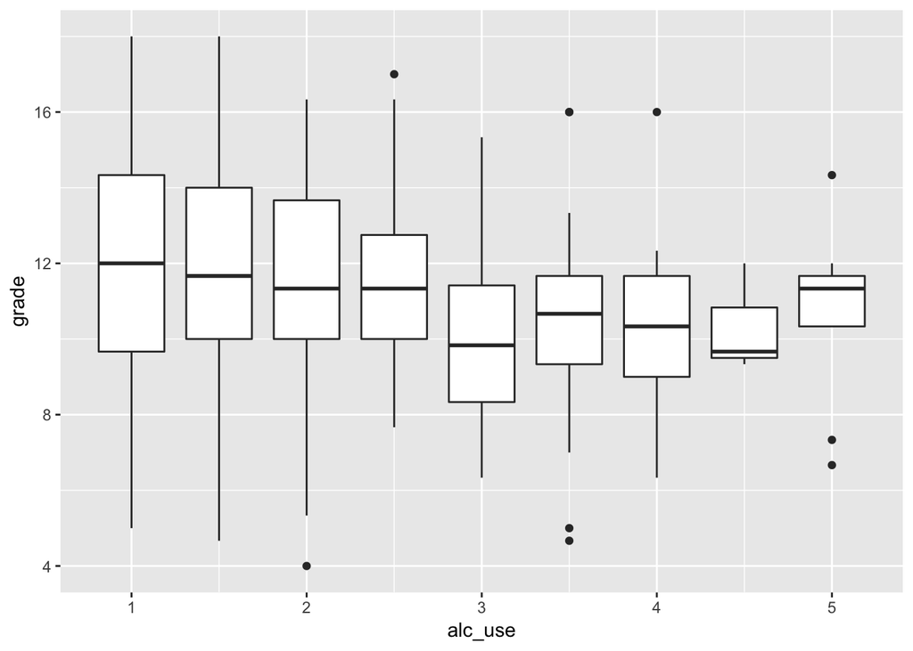

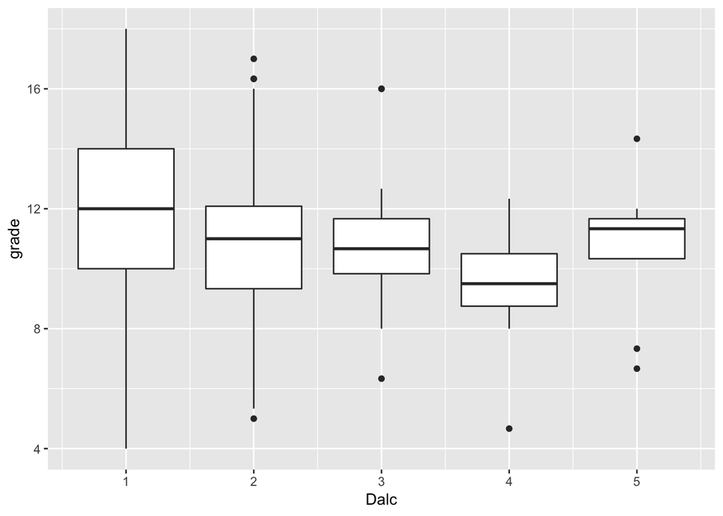

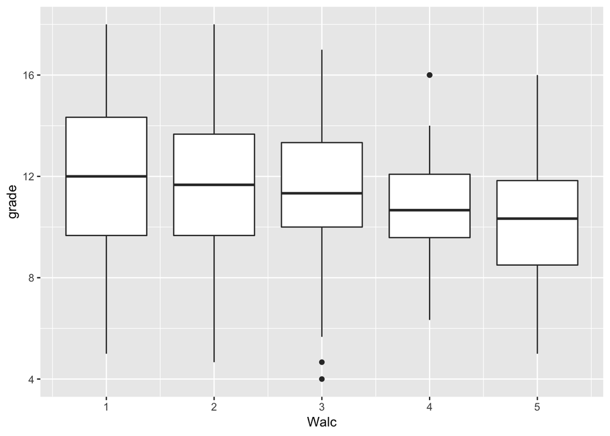

I do the same for absences. The overall trend again proves my hypothesis: the higher alcohol consumption, the more absences.

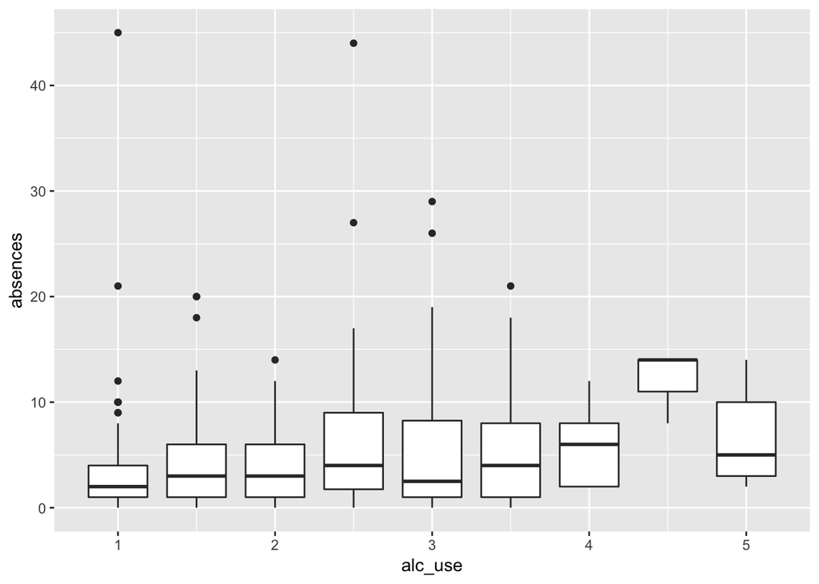

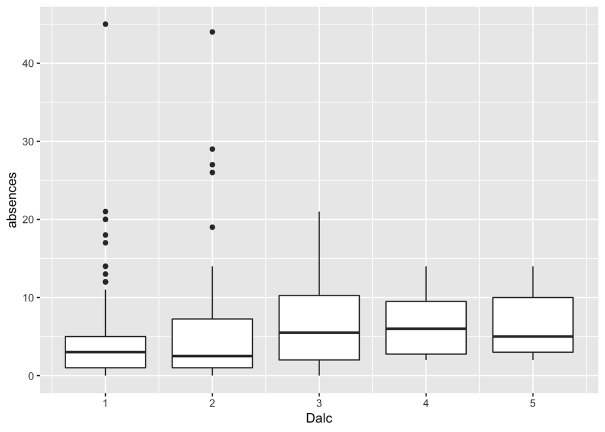

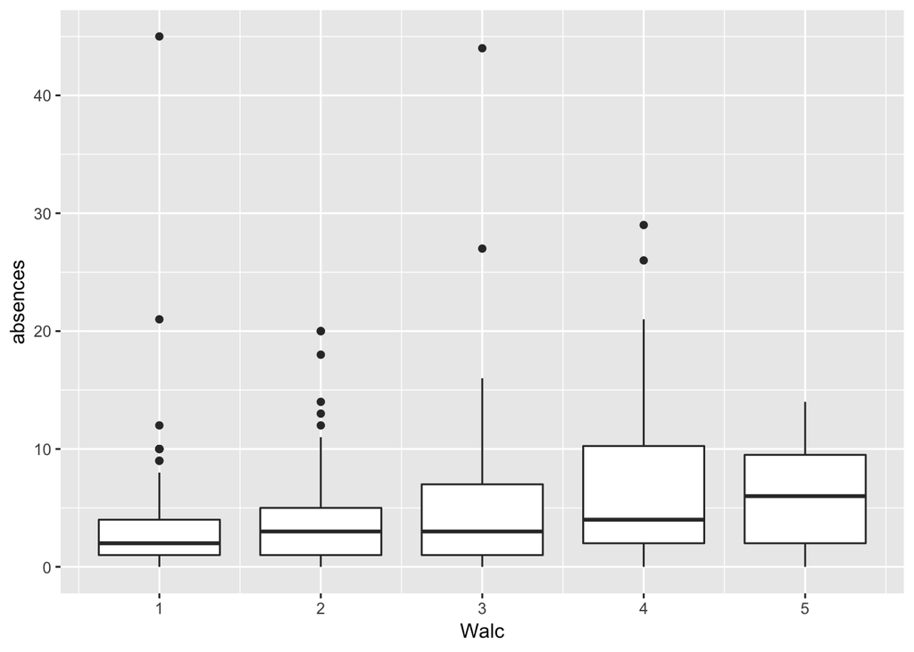

Here it’s clearly seen how going out with friends increases alcohol consumption.

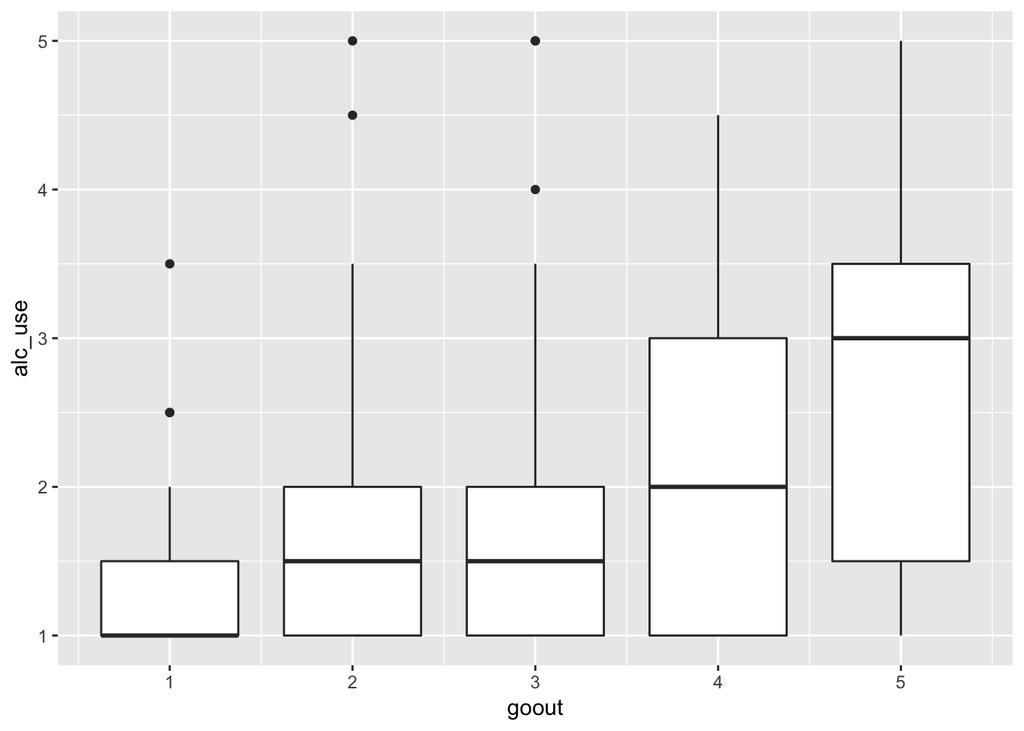

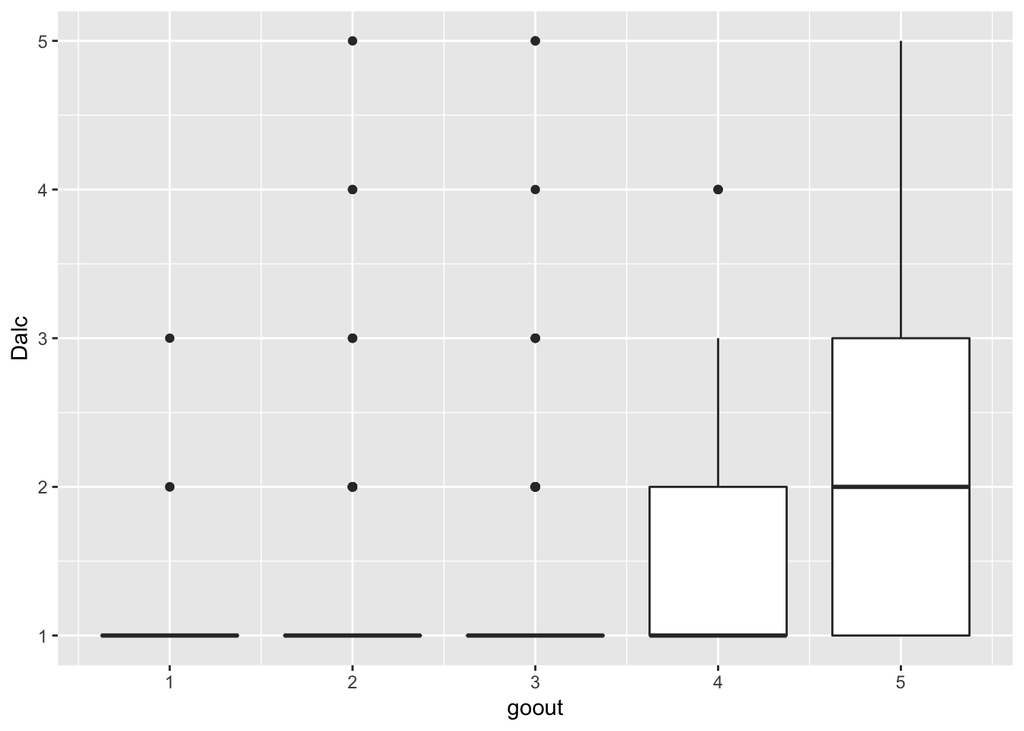

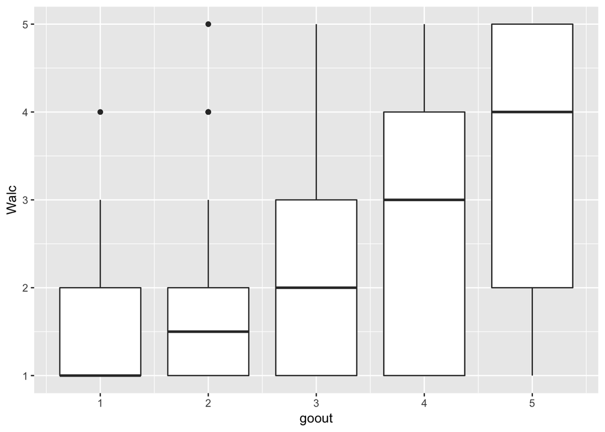

## Building logistic regression model

I built a logistic regression model with the binary high/low alcohol consumption variable as the target and the following explanatory variables:

- sex
- G
- absences
- goout

```r
my_model <- glm(high_use ~ sex + G + absences + goout, data = alc, family = "binomial")
summary(my_model)
```

```
##
## Call:
## glm(formula = high_use ~ sex + G + absences + goout, family = "binomial",
##     data = alc)
##
## Deviance Residuals:
##     Min       1Q   Median       3Q      Max
## -1.9328  -0.8060  -0.5331   0.8238   2.4661
##
## Coefficients:
##             Estimate Std. Error z value Pr(>|z|)
## (Intercept) -3.39721    0.74736  -4.546 5.48e-06 ***
## sexM         0.95272    0.25510   3.735 0.000188 ***
## G           -0.05877    0.04572  -1.286 0.198594
## absences     0.08105    0.02236   3.625 0.000289 ***
## goout        0.70547    0.12070   5.845 5.07e-09 ***
## ---
## Signif. codes:  0 '***' 0.001 '**' 0.01 '*' 0.05 '.' 0.1 ' ' 1
##
## (Dispersion parameter for binomial family taken to be 1)
##
##     Null deviance: 465.68  on 381  degrees of freedom
## Residual deviance: 386.09  on 377  degrees of freedom
## AIC: 396.09
##
## Number of Fisher Scoring iterations: 4
```

```r
coef(my_model)
```

```
## (Intercept)        sexM           G    absences       goout
## -3.39721198  0.95271930 -0.05877270  0.08105372  0.70546954
```

```r
odds <- coef(my_model) %>% exp
ci <- confint(my_model) %>% exp
cbind(odds, ci)
```

```
##                   odds       2.5 %    97.5 %
## (Intercept) 0.03346645 0.007372191 0.1390862
## sexM        2.59275054 1.581774204 4.3094277
## G           0.94292107 0.861487242 1.0310898
## absences    1.08442915 1.039156246 1.1357634
## goout       2.02479718 1.607264661 2.5826300
```

## Predictive power

Firstly, I remove redundant G variable from my model.

```r
my_model_new <- glm(high_use ~ sex + absences + goout, data = alc, family = "binomial")
summary(my_model_new)
```

```
##
## Call:
## glm(formula = high_use ~ sex + absences + goout, family = "binomial",
##     data = alc)
##
## Deviance Residuals:
##     Min       1Q   Median       3Q      Max
## -1.7871  -0.8153  -0.5446   0.8357   2.4740
##
## Coefficients:
##             Estimate Std. Error z value Pr(>|z|)
## (Intercept) -4.16317    0.47506  -8.764  < 2e-16 ***
## sexM         0.95872    0.25459   3.766 0.000166 ***
## absences     0.08418    0.02237   3.764 0.000167 ***
## goout        0.72981    0.11970   6.097 1.08e-09 ***
## ---
## Signif. codes:  0 '***' 0.001 '**' 0.01 '*' 0.05 '.' 0.1 ' ' 1
##
## (Dispersion parameter for binomial family taken to be 1)
##
##     Null deviance: 465.68  on 381  degrees of freedom
## Residual deviance: 387.75  on 378  degrees of freedom
## AIC: 395.75
##
## Number of Fisher Scoring iterations: 4
```

Cross tabulation of predictions versus the actual values:

```r
probabilities <- predict(my_model_new, type = "response")
alc <- mutate(alc, probability = probabilities)
alc <- mutate(alc, prediction = probability > 0.5)
select(alc, sex, G, absences, goout, high_use, probability, prediction) %>% tail(10)
```

```
##     sex         G absences goout high_use probability prediction
## 373   M  4.000000        0     2    FALSE  0.14869987      FALSE
## 374   M  4.666667        7     3     TRUE  0.39514446      FALSE
## 375   F 12.333333        1     3    FALSE  0.13129452      FALSE
## 376   F  7.000000        6     3    FALSE  0.18714923      FALSE
## 377   F  7.000000        2     2    FALSE  0.07342805      FALSE
## 378   F 11.666667        2     4    FALSE  0.25434555      FALSE
## 379   F  5.333333        2     2    FALSE  0.07342805      FALSE
## 380   F  6.666667        3     1    FALSE  0.03989428      FALSE
## 381   M 12.666667        4     5     TRUE  0.68596604       TRUE
## 382   M 10.666667        2     1     TRUE  0.09060457      FALSE
```

```r
table(high_use = alc$high_use, prediction = alc$prediction)
```

```
##         prediction
## high_use FALSE TRUE
##    FALSE   253   15
##    TRUE     65   49
```

As it can be seen from the table, my model correctly classified $253+49=302$ observations and failed with $65+15= 80$ observations. That means **the train error is 0.21**.

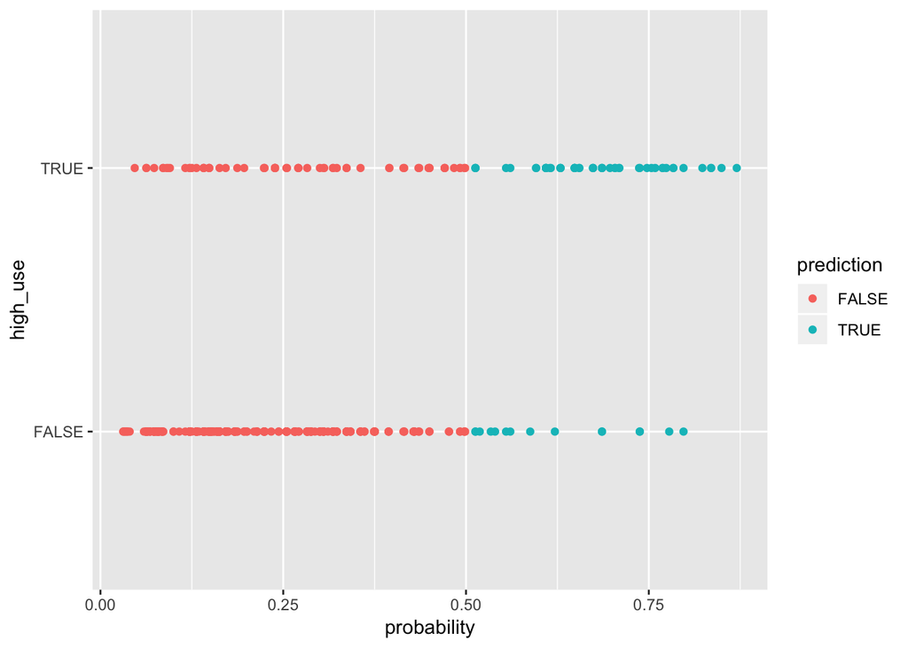

```r
g <- ggplot(alc, aes(x = probability, y = high_use, col = prediction))
g + geom_point()
```

```r
table(high_use = alc$high_use, prediction = alc$prediction) %>% prop.table() %>% addmargins()
```

```
##         prediction
## high_use      FALSE       TRUE        Sum
##    FALSE 0.66230366 0.03926702 0.70157068
##    TRUE  0.17015707 0.12827225 0.29842932
##    Sum   0.83246073 0.16753927 1.00000000
```

Again the average number of incorrectly classified observations (train error).

```r
loss_func <- function(class, prob) {
  n_wrong <- abs(class - prob) > 0.5
  mean(n_wrong)
}
loss_func(class = alc$high_use, prob = alc$probability)
```

```
## [1] 0.2094241
```

## Cross-validation

```r
library(boot)
set.seed(12345)
cv <- cv.glm(data = alc, cost = loss_func, glmfit = my_model, K = 10)
cv$delta[1]
```

[output not shown]

**My model has better test set performance compared to that introduced in DataCamp (0.21 < 0.26)**.

## Comparative analysis of different models

```r
model1 <- glm(high_use ~ school + sex + age + address + famsize + Pstatus + Medu + Fedu + Mjob + Fjob + reason + nursery + internet + guardian + traveltime + studytime + failures + schoolsup + famsup + paid + activities + higher + romantic + famrel + freetime + goout + health + G + absences, data = alc, family = "binomial")
summary(model1)
```

```
##
## Call:
## glm(formula = high_use ~ school + sex + age + address + famsize +
##     Pstatus + Medu + Fedu + Mjob + Fjob + reason + nursery +
##     internet + guardian + traveltime + studytime + failures +
##     schoolsup + famsup + paid + activities + higher + romantic +
##     famrel + freetime + goout + health + G + absences, family = "binomial",
##     data = alc)
##
## Deviance Residuals:
##     Min       1Q   Median       3Q      Max
## -1.8627  -0.6736  -0.3646   0.4919   2.8603
##
## Coefficients:
##                  Estimate Std. Error z value Pr(>|z|)
## (Intercept)      -5.08618    3.14051  -1.620 0.105331
## schoolMS         -0.64084    0.54464  -1.177 0.239348
## sexM              0.78151    0.32800   2.383 0.017186 *
## age               0.11389    0.14891   0.765 0.444378
## addressU         -0.79078    0.41414  -1.909 0.056205 .
## famsizeLE3        0.50798    0.32485   1.564 0.117881
## PstatusT         -0.37621    0.53708  -0.700 0.483638
## Medu              0.04109    0.22063   0.186 0.852248
## Fedu              0.17849    0.19591   0.911 0.362249
## Mjobhealth       -1.05659    0.76284  -1.385 0.166030
## Mjobother        -0.88695    0.49927  -1.776 0.075653 .
## Mjobservices     -0.85942    0.57204  -1.502 0.133002
## Mjobteacher      -0.27721    0.69284  -0.400 0.689078
## Fjobhealth        0.38793    1.19201   0.325 0.744844
## Fjobother         0.83377    0.86355   0.966 0.334284
## Fjobservices      1.40256    0.88332   1.588 0.112324
## Fjobteacher      -0.45614    1.03302  -0.442 0.658807
## reasonhome        0.45824    0.38062   1.204 0.228612
## reasonother       1.48295    0.54116   2.740 0.006138 **
## reasonreputation -0.07672    0.41106  -0.187 0.851945
## nurseryyes       -0.53771    0.36697  -1.465 0.142847
## internetyes       0.06098    0.45571   0.134 0.893544
## guardianmother   -0.79452    0.36578  -2.172 0.029847 *
## guardianother    -0.20035    0.79410  -0.252 0.800812
## traveltime        0.32419    0.23135   1.401 0.161119
```

[output cut: 9 more lines]

```
## freetime          0.30094    0.16736   1.798 0.072142 .
## goout             0.86399    0.15370   5.621  1.9e-08 ***
## health            0.18588    0.11356   1.637 0.101646
## G                 0.03029    0.06251   0.485 0.627981
## absences          0.09011    0.02669   3.376 0.000736 ***
## ---
## Signif. codes:  0 '***' 0.001 '**' 0.01 '*' 0.05 '.' 0.1 ' ' 1
##
## (Dispersion parameter for binomial family taken to be 1)
##
##     Null deviance: 465.68  on 381  degrees of freedom
## Residual deviance: 322.25  on 343  degrees of freedom
## AIC: 400.25
##
## Number of Fisher Scoring iterations: 5
```

I’ll first exclude ‘higher’ variable since it has the highest p-value.

```r
model2 <- glm(high_use ~ school + sex + age + address + famsize + Pstatus + Medu + Fedu + Mjob + Fjob + reason + nursery + guardian + traveltime + studytime + failures + schoolsup + famsup + paid + activities + internet + romantic + famrel + freetime + goout + health + G + absences, data = alc, family = "binomial")
summary(model2)
```

```
##
## Call:
## glm(formula = high_use ~ school + sex + age + address + famsize +
##     Pstatus + Medu + Fedu + Mjob + Fjob + reason + nursery +
##     guardian + traveltime + studytime + failures + schoolsup +
##     famsup + paid + activities + internet + romantic + famrel +
##     freetime + goout + health + G + absences, family = "binomial",
##     data = alc)
##
## Deviance Residuals:
##     Min       1Q   Median       3Q      Max
## -1.8574  -0.6738  -0.3632   0.4907   2.8583
##
## Coefficients:
##                  Estimate Std. Error z value Pr(>|z|)
## (Intercept)      -5.16352    3.03321  -1.702 0.088694 .
## schoolMS         -0.64662    0.54137  -1.194 0.232319
## sexM              0.78486    0.32612   2.407 0.016098 *
## age               0.11609    0.14703   0.790 0.429755
## addressU         -0.79095    0.41414  -1.910 0.056147 .
## famsizeLE3        0.50761    0.32479   1.563 0.118079
## PstatusT         -0.37587    0.53680  -0.700 0.483804
## Medu              0.04079    0.22063   0.185 0.853332
## Fedu              0.17683    0.19519   0.906 0.364963
## Mjobhealth       -1.05742    0.76241  -1.387 0.165461
## Mjobother        -0.88794    0.49891  -1.780 0.075115 .
## Mjobservices     -0.86077    0.57168  -1.506 0.132147
## Mjobteacher      -0.27882    0.69248  -0.403 0.687213
## Fjobhealth        0.38566    1.19171   0.324 0.746227
## Fjobother         0.82881    0.86143   0.962 0.335983
## Fjobservices      1.39953    0.88221   1.586 0.112650
## Fjobteacher      -0.45584    1.03265  -0.441 0.658903
## reasonhome        0.45547    0.37950   1.200 0.230073
## reasonother       1.48068    0.54033   2.740 0.006138 **
## reasonreputation -0.07731    0.41095  -0.188 0.850779
## nurseryyes       -0.53567    0.36625  -1.463 0.143581
## guardianmother   -0.79426    0.36571  -2.172 0.029868 *
## guardianother    -0.20143    0.79454  -0.254 0.799865
## traveltime        0.32371    0.23123   1.400 0.161537
## studytime        -0.31702    0.20680  -1.533 0.125270
```

[output cut: 8 more lines]

```
## freetime          0.30097    0.16740   1.798 0.072196 .
## goout             0.86397    0.15372   5.620  1.9e-08 ***
## health            0.18585    0.11355   1.637 0.101678
## G                 0.02911    0.06127   0.475 0.634698
## absences          0.09018    0.02663   3.386 0.000709 ***
## ---
## Signif. codes:  0 '***' 0.001 '**' 0.01 '*' 0.05 '.' 0.1 ' ' 1
##
## (Dispersion parameter for binomial family taken to be 1)
##
##     Null deviance: 465.68  on 381  degrees of freedom
## Residual deviance: 322.26  on 344  degrees of freedom
## AIC: 398.26
##
## Number of Fisher Scoring iterations: 5
```

Next, I exclude ‘internet’.

```r
model3 <- glm(high_use ~ school + sex + age + address + famsize + Pstatus + Medu + Fedu + Mjob + Fjob + reason + nursery + guardian + traveltime + studytime + failures + schoolsup + famsup + paid + activities + romantic + famrel + freetime + goout + health + G + absences, data = alc, family = "binomial")
summary(model3)
```

```
##
## Call:
## glm(formula = high_use ~ school + sex + age + address + famsize +
##     Pstatus + Medu + Fedu + Mjob + Fjob + reason + nursery +
##     guardian + traveltime + studytime + failures + schoolsup +
##     famsup + paid + activities + romantic + famrel + freetime +
##     goout + health + G + absences, family = "binomial", data = alc)
##
## Deviance Residuals:
##     Min       1Q   Median       3Q      Max
## -1.8526  -0.6770  -0.3622   0.4919   2.8617
##
## Coefficients:
##                  Estimate Std. Error z value Pr(>|z|)
## (Intercept)      -5.12643    3.02329  -1.696 0.089953 .
## schoolMS         -0.64335    0.54030  -1.191 0.233762
## sexM              0.78696    0.32577   2.416 0.015705 *
## age               0.11476    0.14669   0.782 0.434052
## addressU         -0.77768    0.40361  -1.927 0.054003 .
## famsizeLE3        0.50774    0.32474   1.564 0.117935
## PstatusT         -0.37073    0.53555  -0.692 0.488792
## Medu              0.04105    0.22066   0.186 0.852433
## Fedu              0.17836    0.19492   0.915 0.360182
## Mjobhealth       -1.03660    0.74870  -1.385 0.166196
## Mjobother        -0.87204    0.48633  -1.793 0.072960 .
## Mjobservices     -0.84337    0.55871  -1.510 0.131170
## Mjobteacher      -0.25946    0.67923  -0.382 0.702470
## Fjobhealth        0.36101    1.18006   0.306 0.759660
## Fjobother         0.81761    0.85792   0.953 0.340587
## Fjobservices      1.39232    0.88075   1.581 0.113918
## Fjobteacher      -0.47387    1.02491  -0.462 0.643828
## reasonhome        0.45432    0.37941   1.197 0.231139
## reasonother       1.47962    0.54012   2.739 0.006154 **
## reasonreputation -0.07618    0.41073  -0.185 0.852849
## nurseryyes       -0.54084    0.36427  -1.485 0.137617
## guardianmother   -0.79425    0.36583  -2.171 0.029926 *
## guardianother    -0.20325    0.79394  -0.256 0.797952
## traveltime        0.32472    0.23118   1.405 0.160143
## studytime        -0.31585    0.20664  -1.529 0.126383
## failures          0.21936    0.26438   0.830 0.406692
## schoolsupyes      0.08158    0.46769   0.174 0.861522
## famsupyes        -0.08084    0.32320  -0.250 0.802493
## paidyes           0.60223    0.31486   1.913 0.055788 .
## activitiesyes    -0.57752    0.30665  -1.883 0.059656 .
## romanticyes      -0.53955    0.32729  -1.649 0.099241 .
## famrel           -0.56305    0.16644  -3.383 0.000717 ***
## freetime          0.30163    0.16727   1.803 0.071349 .
## goout             0.86537    0.15345   5.639 1.71e-08 ***
## health            0.18475    0.11324   1.632 0.102782
## G                 0.02933    0.06126   0.479 0.632078
## absences          0.09074    0.02633   3.447 0.000568 ***
## ---
## Signif. codes:  0 '***' 0.001 '**' 0.01 '*' 0.05 '.' 0.1 ' ' 1
##
## (Dispersion parameter for binomial family taken to be 1)
##
##     Null deviance: 465.68  on 381  degrees of freedom
## Residual deviance: 322.28  on 345  degrees of freedom
## AIC: 396.28
##
## Number of Fisher Scoring iterations: 5
```

Exclude ‘schoolsup’.

```r
model4 <- glm(high_use ~ school + sex + age + address + famsize + Pstatus + Medu + Fedu + Mjob + Fjob + reason + nursery + guardian + traveltime + studytime + failures + famsup + paid + activities + romantic + famrel + freetime + goout + health + G + absences, data = alc, family = "binomial")
summary(model4)
```

```
##
## Call:
## glm(formula = high_use ~ school + sex + age + address + famsize +
##     Pstatus + Medu + Fedu + Mjob + Fjob + reason + nursery +
##     guardian + traveltime + studytime + failures + famsup + paid +
##     activities + romantic + famrel + freetime + goout + health +
##     G + absences, family = "binomial", data = alc)
##
## Deviance Residuals:
##     Min       1Q   Median       3Q      Max
## -1.8518  -0.6760  -0.3640   0.4924   2.8563
##
## Coefficients:
##                  Estimate Std. Error z value Pr(>|z|)
## (Intercept)      -4.99756    2.93284  -1.704 0.088381 .
## schoolMS         -0.64816    0.53940  -1.202 0.229505
## sexM              0.78009    0.32332   2.413 0.015832 *
## age               0.10936    0.14343   0.762 0.445781
## addressU         -0.77332    0.40302  -1.919 0.055010 .
## famsizeLE3        0.50645    0.32471   1.560 0.118826
## PstatusT         -0.37181    0.53587  -0.694 0.487787
## Medu              0.04134    0.22084   0.187 0.851526
## Fedu              0.17751    0.19489   0.911 0.362382
## Mjobhealth       -1.04274    0.74837  -1.393 0.163516
## Mjobother        -0.87295    0.48682  -1.793 0.072949 .
## Mjobservices     -0.84168    0.55876  -1.506 0.131980
## Mjobteacher      -0.26621    0.67849  -0.392 0.694795
## Fjobhealth        0.37294    1.17951   0.316 0.751864
## Fjobother         0.81064    0.85833   0.944 0.344946
## Fjobservices      1.38763    0.88152   1.574 0.115457
## Fjobteacher      -0.46898    1.02551  -0.457 0.647445
## reasonhome        0.45543    0.37949   1.200 0.230094
## reasonother       1.47659    0.53962   2.736 0.006213 **
## reasonreputation -0.07490    0.41084  -0.182 0.855341
## nurseryyes       -0.53863    0.36391  -1.480 0.138843
## guardianmother   -0.79436    0.36586  -2.171 0.029916 *
## guardianother    -0.19941    0.79321  -0.251 0.801506
## traveltime        0.32865    0.23020   1.428 0.153382
## studytime        -0.31527    0.20662  -1.526 0.127041
## failures          0.21825    0.26454   0.825 0.409364
## famsupyes        -0.07937    0.32326  -0.246 0.806055
## paidyes           0.60083    0.31480   1.909 0.056309 .
## activitiesyes    -0.57270    0.30545  -1.875 0.060798 .
## romanticyes      -0.54102    0.32722  -1.653 0.098258 .
## famrel           -0.56320    0.16645  -3.384 0.000716 ***
## freetime          0.30171    0.16728   1.804 0.071297 .
## goout             0.86439    0.15330   5.638 1.72e-08 ***
## health            0.18375    0.11304   1.626 0.104055
## G                 0.02734    0.06016   0.454 0.649500
## absences          0.09068    0.02631   3.447 0.000566 ***
## ---
## Signif. codes:  0 '***' 0.001 '**' 0.01 '*' 0.05 '.' 0.1 ' ' 1
##
## (Dispersion parameter for binomial family taken to be 1)
##
##     Null deviance: 465.68  on 381  degrees of freedom
## Residual deviance: 322.31  on 346  degrees of freedom
## AIC: 394.31
##
## Number of Fisher Scoring iterations: 5
```

Exclude ‘reason’.

```r
model5 <- glm(high_use ~ school + sex + age + address + famsize + Pstatus + Medu + Fedu + Mjob + Fjob + nursery + guardian + traveltime + studytime + failures + famsup + paid + activities + romantic + famrel + freetime + goout + health + G + absences, data = alc, family = "binomial")
summary(model5)
```

```
##
## Call:
## glm(formula = high_use ~ school + sex + age + address + famsize +
##     Pstatus + Medu + Fedu + Mjob + Fjob + nursery + guardian +
##     traveltime + studytime + failures + famsup + paid + activities +
##     romantic + famrel + freetime + goout + health + G + absences,
##     family = "binomial", data = alc)
##
## Deviance Residuals:
##     Min       1Q   Median       3Q      Max
## -1.7233  -0.6897  -0.3817   0.5445   2.8298
##
## Coefficients:
##                Estimate Std. Error z value Pr(>|z|)
## (Intercept)    -4.08669    2.82620  -1.446 0.148176
## schoolMS       -0.37473    0.51525  -0.727 0.467062
## sexM            0.80819    0.31408   2.573 0.010076 *
## age             0.08107    0.13849   0.585 0.558293
## addressU       -0.74109    0.38538  -1.923 0.054482 .
## famsizeLE3      0.40991    0.31949   1.283 0.199487
## PstatusT       -0.30034    0.51712  -0.581 0.561375
## Medu            0.03289    0.21793   0.151 0.880028
## Fedu            0.14225    0.19110   0.744 0.456646
## Mjobhealth     -0.78721    0.71296  -1.104 0.269533
## Mjobother      -0.77963    0.46465  -1.678 0.093368 .
## Mjobservices   -0.76066    0.53936  -1.410 0.158450
## Mjobteacher    -0.23182    0.65554  -0.354 0.723616
## Fjobhealth      0.50492    1.12970   0.447 0.654907
## Fjobother       0.71126    0.85002   0.837 0.402726
## Fjobservices    1.35875    0.86839   1.565 0.117660
## Fjobteacher    -0.27718    1.00736  -0.275 0.783198
## nurseryyes     -0.46942    0.35616  -1.318 0.187501
## guardianmother -0.70359    0.35591  -1.977 0.048056 *
## guardianother  -0.09891    0.76125  -0.130 0.896616
## traveltime      0.26362    0.22247   1.185 0.236020
## studytime      -0.37944    0.20093  -1.888 0.058965 .
## failures        0.24625    0.26237   0.939 0.347951
## famsupyes      -0.13318    0.31839  -0.418 0.675731
## paidyes         0.74076    0.30830   2.403 0.016273 *
## activitiesyes  -0.57741    0.29691  -1.945 0.051807 .
## romanticyes    -0.41679    0.31740  -1.313 0.189134
## famrel         -0.51098    0.16230  -3.148 0.001642 **
## freetime        0.25347    0.16090   1.575 0.115178
## goout           0.80830    0.14749   5.480 4.25e-08 ***
## health          0.17971    0.10908   1.648 0.099452 .
## G               0.02514    0.05967   0.421 0.673482
## absences        0.09061    0.02511   3.608 0.000309 ***
## ---
## Signif. codes:  0 '***' 0.001 '**' 0.01 '*' 0.05 '.' 0.1 ' ' 1
##
## (Dispersion parameter for binomial family taken to be 1)
##
##     Null deviance: 465.68  on 381  degrees of freedom
## Residual deviance: 331.49  on 349  degrees of freedom
## AIC: 397.49
##
## Number of Fisher Scoring iterations: 5
```

Exclude ‘Medu’.

```r
model6 <- glm(high_use ~ school + sex + age + address + famsize + Pstatus  + Fedu + Mjob + Fjob + nursery + guardian + traveltime + studytime + failures + famsup + paid + activities + romantic + famrel + freetime + goout + health + G + absences, data = alc, family = "binomial")
summary(model6)
```

```
##
## Call:
## glm(formula = high_use ~ school + sex + age + address + famsize +
##     Pstatus + Fedu + Mjob + Fjob + nursery + guardian + traveltime +
##     studytime + failures + famsup + paid + activities + romantic +
##     famrel + freetime + goout + health + G + absences, family = "binomial",
##     data = alc)
##
## Deviance Residuals:
##     Min       1Q   Median       3Q      Max
## -1.7206  -0.6903  -0.3776   0.5420   2.8358
##
## Coefficients:
##                Estimate Std. Error z value Pr(>|z|)
## (Intercept)    -4.04382    2.81011  -1.439 0.150144
## schoolMS       -0.37542    0.51522  -0.729 0.466206
## sexM            0.80872    0.31402   2.575 0.010012 *
## age             0.08011    0.13829   0.579 0.562384
## addressU       -0.74255    0.38544  -1.926 0.054042 .
## famsizeLE3      0.40556    0.31823   1.274 0.202512
## PstatusT       -0.30904    0.51358  -0.602 0.547349
## Fedu            0.15686    0.16484   0.952 0.341291
## Mjobhealth     -0.73995    0.63984  -1.156 0.247492
## Mjobother      -0.76332    0.45169  -1.690 0.091047 .
## Mjobservices   -0.73076    0.50130  -1.458 0.144918
## Mjobteacher    -0.17865    0.55334  -0.323 0.746798
## Fjobhealth      0.49960    1.12806   0.443 0.657850
## Fjobother       0.71431    0.84981   0.841 0.400604
## Fjobservices    1.35474    0.86799   1.561 0.118577
## Fjobteacher    -0.27451    1.00763  -0.272 0.785290
## nurseryyes     -0.46556    0.35497  -1.312 0.189681
## guardianmother -0.70104    0.35553  -1.972 0.048632 *
## guardianother  -0.09563    0.76085  -0.126 0.899979
## traveltime      0.26331    0.22261   1.183 0.236862
## studytime      -0.37745    0.20072  -1.880 0.060045 .
## failures        0.24420    0.26190   0.932 0.351119
## famsupyes      -0.13375    0.31829  -0.420 0.674323
## paidyes         0.74288    0.30789   2.413 0.015829 *
## activitiesyes  -0.57721    0.29685  -1.944 0.051843 .
## romanticyes    -0.41266    0.31602  -1.306 0.191622
## famrel         -0.51025    0.16226  -3.145 0.001663 **
## freetime        0.25343    0.16088   1.575 0.115190
## goout           0.80866    0.14744   5.485 4.14e-08 ***
## health          0.17779    0.10825   1.642 0.100488
## G               0.02524    0.05971   0.423 0.672533
## absences        0.09107    0.02491   3.656 0.000256 ***
## ---
## Signif. codes:  0 '***' 0.001 '**' 0.01 '*' 0.05 '.' 0.1 ' ' 1
##
## (Dispersion parameter for binomial family taken to be 1)
##
##     Null deviance: 465.68  on 381  degrees of freedom
## Residual deviance: 331.52  on 350  degrees of freedom
## AIC: 395.52
##
## Number of Fisher Scoring iterations: 5
```

Exclude ‘guardian’.

```r
model7 <- glm(high_use ~ school + sex + age + address + famsize + Pstatus  + Fedu + Mjob + Fjob + nursery + traveltime + studytime + failures + famsup + paid + activities + romantic + famrel + freetime + goout + health + G + absences, data = alc, family = "binomial")
summary(model7)
```

```
##
## Call:
## glm(formula = high_use ~ school + sex + age + address + famsize +
##     Pstatus + Fedu + Mjob + Fjob + nursery + traveltime + studytime +
##     failures + famsup + paid + activities + romantic + famrel +
##     freetime + goout + health + G + absences, family = "binomial",
##     data = alc)
##
## Deviance Residuals:
##     Min       1Q   Median       3Q      Max
## -1.7556  -0.6944  -0.3900   0.5608   2.8092
##
## Coefficients:
##               Estimate Std. Error z value Pr(>|z|)
## (Intercept)   -5.37597    2.71742  -1.978 0.047891 *
## schoolMS      -0.31932    0.50913  -0.627 0.530536
## sexM           0.84575    0.31024   2.726 0.006409 **
## age            0.10537    0.13449   0.783 0.433364
## addressU      -0.60479    0.37449  -1.615 0.106315
## famsizeLE3     0.36606    0.31509   1.162 0.245332
## PstatusT      -0.20685    0.50488  -0.410 0.682021
## Fedu           0.21276    0.15975   1.332 0.182911
## Mjobhealth    -0.65522    0.63190  -1.037 0.299777
## Mjobother     -0.64460    0.44434  -1.451 0.146867
## Mjobservices  -0.73536    0.49809  -1.476 0.139844
## Mjobteacher   -0.30633    0.54259  -0.565 0.572373
## Fjobhealth     0.64804    1.10839   0.585 0.558776
## Fjobother      0.70111    0.85604   0.819 0.412774
## Fjobservices   1.46612    0.87363   1.678 0.093311 .
## Fjobteacher   -0.24247    1.01118  -0.240 0.810496
## nurseryyes    -0.51895    0.34878  -1.488 0.136771
## traveltime     0.31984    0.21522   1.486 0.137253
## studytime     -0.36204    0.19967  -1.813 0.069802 .
## failures       0.22648    0.25938   0.873 0.382579
## famsupyes     -0.11796    0.31562  -0.374 0.708588
## paidyes        0.69786    0.30492   2.289 0.022100 *
## activitiesyes -0.56548    0.29312  -1.929 0.053711 .
## romanticyes   -0.42088    0.31353  -1.342 0.179459
## famrel        -0.50940    0.15998  -3.184 0.001452 **
## freetime       0.27448    0.15962   1.720 0.085504 .
## goout          0.77233    0.14503   5.325 1.01e-07 ***
## health         0.18032    0.10795   1.670 0.094840 .
## G              0.02502    0.05960   0.420 0.674599
## absences       0.08615    0.02487   3.464 0.000532 ***
## ---
## Signif. codes:  0 '***' 0.001 '**' 0.01 '*' 0.05 '.' 0.1 ' ' 1
##
## (Dispersion parameter for binomial family taken to be 1)
##
##     Null deviance: 465.68  on 381  degrees of freedom
## Residual deviance: 335.74  on 352  degrees of freedom
## AIC: 395.74
##
## Number of Fisher Scoring iterations: 5
```

Exclude ‘Fjob’.

```r
model8 <- glm(high_use ~ school + sex + age + address + famsize + Pstatus  + Fedu + Mjob + nursery + traveltime + studytime + failures + famsup + paid + activities + romantic + famrel + freetime + goout + health + G + absences, data = alc, family = "binomial")
summary(model8)
```

```
##
## Call:
## glm(formula = high_use ~ school + sex + age + address + famsize +
##     Pstatus + Fedu + Mjob + nursery + traveltime + studytime +
##     failures + famsup + paid + activities + romantic + famrel +
##     freetime + goout + health + G + absences, family = "binomial",
##     data = alc)
##
## Deviance Residuals:
##     Min       1Q   Median       3Q      Max
## -1.7502  -0.7345  -0.4100   0.6071   2.7421
##
## Coefficients:
##                 Estimate Std. Error z value Pr(>|z|)
## (Intercept)   -4.035e+00  2.537e+00  -1.590 0.111735
## schoolMS      -1.884e-01  5.049e-01  -0.373 0.708985
## sexM           8.385e-01  3.058e-01   2.741 0.006116 **
## age            8.765e-02  1.310e-01   0.669 0.503568
## addressU      -6.174e-01  3.712e-01  -1.663 0.096280 .
## famsizeLE3     3.896e-01  3.079e-01   1.265 0.205804
## PstatusT      -4.753e-02  4.823e-01  -0.099 0.921500
## Fedu           1.491e-01  1.470e-01   1.014 0.310460
## Mjobhealth    -4.459e-01  6.094e-01  -0.732 0.464321
## Mjobother     -5.778e-01  4.236e-01  -1.364 0.172577
## Mjobservices  -4.802e-01  4.729e-01  -1.015 0.309909
## Mjobteacher   -2.773e-01  5.242e-01  -0.529 0.596841
## nurseryyes    -5.339e-01  3.404e-01  -1.568 0.116772
## traveltime     2.705e-01  2.096e-01   1.291 0.196798
## studytime     -3.032e-01  1.955e-01  -1.551 0.120882
## failures       2.388e-01  2.528e-01   0.945 0.344868
## famsupyes     -2.137e-01  3.066e-01  -0.697 0.485728
## paidyes        7.557e-01  2.965e-01   2.549 0.010801 *
## activitiesyes -4.775e-01  2.846e-01  -1.678 0.093354 .
## romanticyes   -4.373e-01  3.037e-01  -1.440 0.149935
## famrel        -4.428e-01  1.561e-01  -2.836 0.004563 **
## freetime       1.867e-01  1.522e-01   1.227 0.219818
## goout          7.717e-01  1.415e-01   5.455  4.9e-08 ***
## health         1.689e-01  1.054e-01   1.603 0.108911
## G             -7.315e-05  5.754e-02  -0.001 0.998986
## absences       8.610e-02  2.389e-02   3.604 0.000313 ***
## ---
## Signif. codes:  0 '***' 0.001 '**' 0.01 '*' 0.05 '.' 0.1 ' ' 1
##
## (Dispersion parameter for binomial family taken to be 1)
##
##     Null deviance: 465.68  on 381  degrees of freedom
## Residual deviance: 346.83  on 356  degrees of freedom
## AIC: 398.83
##
## Number of Fisher Scoring iterations: 5
```

Exclude G.

```r
model9 <- glm(high_use ~ school + sex + age + address + famsize + Pstatus  + Fedu + Mjob + nursery + traveltime + studytime + failures + famsup + paid + activities + romantic + famrel + freetime + goout + health + absences, data = alc, family = "binomial")
summary(model9)
```

```
##
## Call:
## glm(formula = high_use ~ school + sex + age + address + famsize +
##     Pstatus + Fedu + Mjob + nursery + traveltime + studytime +
##     failures + famsup + paid + activities + romantic + famrel +
##     freetime + goout + health + absences, family = "binomial",
##     data = alc)
##
## Deviance Residuals:
##     Min       1Q   Median       3Q      Max
## -1.7502  -0.7345  -0.4100   0.6072   2.7420
##
## Coefficients:
##               Estimate Std. Error z value Pr(>|z|)
## (Intercept)   -4.03619    2.40260  -1.680 0.092971 .
## schoolMS      -0.18840    0.50380  -0.374 0.708433
## sexM           0.83848    0.30577   2.742 0.006104 **
## age            0.08766    0.13082   0.670 0.502813
## addressU      -0.61747    0.36997  -1.669 0.095124 .
## famsizeLE3     0.38956    0.30580   1.274 0.202698
## PstatusT      -0.04749    0.48165  -0.099 0.921448
## Fedu           0.14905    0.14602   1.021 0.307398
## Mjobhealth    -0.44602    0.60353  -0.739 0.459891
## Mjobother     -0.57784    0.42292  -1.366 0.171840
## Mjobservices  -0.48031    0.46775  -1.027 0.304491
## Mjobteacher   -0.27730    0.52365  -0.530 0.596414
## nurseryyes    -0.53387    0.34034  -1.569 0.116739
## traveltime     0.27050    0.20904   1.294 0.195656
## studytime     -0.30324    0.19366  -1.566 0.117386
## failures       0.23890    0.24469   0.976 0.328890
## famsupyes     -0.21369    0.30519  -0.700 0.483809
## paidyes        0.75566    0.29623   2.551 0.010745 *
## activitiesyes -0.47755    0.28359  -1.684 0.092195 .
## romanticyes   -0.43730    0.30346  -1.441 0.149569
## famrel        -0.44285    0.15613  -2.836 0.004562 **
## freetime       0.18671    0.15196   1.229 0.219175
## goout          0.77170    0.13883   5.559 2.72e-08 ***
## health         0.16892    0.10409   1.623 0.104611
## absences       0.08610    0.02376   3.623 0.000291 ***
## ---
## Signif. codes:  0 '***' 0.001 '**' 0.01 '*' 0.05 '.' 0.1 ' ' 1
##
## (Dispersion parameter for binomial family taken to be 1)
##
##     Null deviance: 465.68  on 381  degrees of freedom
## Residual deviance: 346.83  on 357  degrees of freedom
## AIC: 396.83
##
## Number of Fisher Scoring iterations: 5
```

Exclude P-status.

```r
model10 <- glm(high_use ~ school + sex + age + address + famsize  + Fedu + Mjob + nursery + traveltime + studytime + failures + famsup + paid + activities + romantic + famrel + freetime + goout + health + absences, data = alc, family = "binomial")
summary(model10)
```

```
##
## Call:
## glm(formula = high_use ~ school + sex + age + address + famsize +
##     Fedu + Mjob + nursery + traveltime + studytime + failures +
##     famsup + paid + activities + romantic + famrel + freetime +
##     goout + health + absences, family = "binomial", data = alc)
##
## Deviance Residuals:
##     Min       1Q   Median       3Q      Max
## -1.7485  -0.7328  -0.4104   0.6072   2.7401
##
## Coefficients:
##               Estimate Std. Error z value Pr(>|z|)
## (Intercept)   -4.07722    2.36799  -1.722 0.085104 .
## schoolMS      -0.19133    0.50288  -0.380 0.703603
## sexM           0.83745    0.30563   2.740 0.006142 **
## age            0.08763    0.13091   0.669 0.503245
## addressU      -0.61816    0.36974  -1.672 0.094548 .
## famsizeLE3     0.39340    0.30323   1.297 0.194508
## Fedu           0.15066    0.14509   1.038 0.299092
## Mjobhealth    -0.44341    0.60284  -0.736 0.462014
## Mjobother     -0.57441    0.42147  -1.363 0.172918
## Mjobservices  -0.47620    0.46587  -1.022 0.306699
## Mjobteacher   -0.27474    0.52281  -0.526 0.599234
## nurseryyes    -0.53237    0.34004  -1.566 0.117442
## traveltime     0.27030    0.20895   1.294 0.195798
## studytime     -0.30282    0.19364  -1.564 0.117852
## failures       0.23860    0.24468   0.975 0.329489
## famsupyes     -0.21422    0.30512  -0.702 0.482631
## paidyes        0.75261    0.29457   2.555 0.010619 *
## activitiesyes -0.48062    0.28185  -1.705 0.088159 .
## romanticyes   -0.43742    0.30351  -1.441 0.149529
## famrel        -0.44357    0.15610  -2.842 0.004490 **
## freetime       0.18578    0.15164   1.225 0.220529
## goout          0.77149    0.13881   5.558 2.73e-08 ***
## health         0.16865    0.10410   1.620 0.105226
## absences       0.08629    0.02367   3.646 0.000266 ***
## ---
## Signif. codes:  0 '***' 0.001 '**' 0.01 '*' 0.05 '.' 0.1 ' ' 1
##
## (Dispersion parameter for binomial family taken to be 1)
##
##     Null deviance: 465.68  on 381  degrees of freedom
## Residual deviance: 346.84  on 358  degrees of freedom
## AIC: 394.84
##
## Number of Fisher Scoring iterations: 5
```

Exclude ‘school’.

```r
model11 <- glm(high_use ~ sex + age + address + famsize  + Fedu + Mjob + nursery + traveltime + studytime + failures + famsup + paid + activities + romantic + famrel + freetime + goout + health + absences, data = alc, family = "binomial")
summary(model11)
```

```
##
## Call:
## glm(formula = high_use ~ sex + age + address + famsize + Fedu +
##     Mjob + nursery + traveltime + studytime + failures + famsup +
##     paid + activities + romantic + famrel + freetime + goout +
##     health + absences, family = "binomial", data = alc)
##
## Deviance Residuals:
##     Min       1Q   Median       3Q      Max
## -1.8048  -0.7178  -0.4131   0.6079   2.7441
##
## Coefficients:
##               Estimate Std. Error z value Pr(>|z|)
## (Intercept)   -3.88938    2.31842  -1.678 0.093425 .
## sexM           0.84767    0.30439   2.785 0.005355 **
## age            0.07176    0.12419   0.578 0.563382
## addressU      -0.58304    0.35828  -1.627 0.103666
## famsizeLE3     0.38897    0.30273   1.285 0.198840
## Fedu           0.14800    0.14481   1.022 0.306765
## Mjobhealth    -0.44447    0.60316  -0.737 0.461185
## Mjobother     -0.57757    0.42152  -1.370 0.170623
## Mjobservices  -0.47899    0.46578  -1.028 0.303787
## Mjobteacher   -0.28195    0.52195  -0.540 0.589068
## nurseryyes    -0.52770    0.34026  -1.551 0.120933
## traveltime     0.25883    0.20666   1.252 0.210407
## studytime     -0.29421    0.19193  -1.533 0.125311
## failures       0.24598    0.24340   1.011 0.312209
## famsupyes     -0.19733    0.30159  -0.654 0.512910
## paidyes        0.74342    0.29336   2.534 0.011273 *
## activitiesyes -0.47343    0.28114  -1.684 0.092190 .
## romanticyes   -0.44151    0.30329  -1.456 0.145459
## famrel        -0.43970    0.15542  -2.829 0.004669 **
## freetime       0.18011    0.15104   1.192 0.233076
## goout          0.77465    0.13867   5.586 2.32e-08 ***
## health         0.17097    0.10387   1.646 0.099751 .
## absences       0.08742    0.02345   3.728 0.000193 ***
## ---
## Signif. codes:  0 '***' 0.001 '**' 0.01 '*' 0.05 '.' 0.1 ' ' 1
##
## (Dispersion parameter for binomial family taken to be 1)
##
##     Null deviance: 465.68  on 381  degrees of freedom
## Residual deviance: 346.98  on 359  degrees of freedom
## AIC: 392.98
##
## Number of Fisher Scoring iterations: 5
```

Exclude ‘Mjob’.

```r
model12 <- glm(high_use ~ sex + age + address + famsize  + Fedu + nursery + traveltime + studytime + failures + famsup + paid + activities + romantic + famrel + freetime + goout + health + absences, data = alc, family = "binomial")
summary(model12)
```

```
##
## Call:
## glm(formula = high_use ~ sex + age + address + famsize + Fedu +
##     nursery + traveltime + studytime + failures + famsup + paid +
##     activities + romantic + famrel + freetime + goout + health +
##     absences, family = "binomial", data = alc)
##
## Deviance Residuals:
##     Min       1Q   Median       3Q      Max
## -1.8619  -0.7330  -0.4157   0.6417   2.7013
##
## Coefficients:
##               Estimate Std. Error z value Pr(>|z|)
## (Intercept)   -4.20455    2.30228  -1.826 0.067811 .
## sexM           0.82162    0.29728   2.764 0.005714 **
## age            0.07107    0.12374   0.574 0.565714
## addressU      -0.63445    0.35258  -1.799 0.071945 .
## famsizeLE3     0.39362    0.30014   1.311 0.189696
## Fedu           0.17187    0.13554   1.268 0.204764
## nurseryyes    -0.51188    0.33565  -1.525 0.127254
## traveltime     0.27087    0.20758   1.305 0.191928
## studytime     -0.29902    0.18935  -1.579 0.114291
## failures       0.25621    0.24275   1.055 0.291211
## famsupyes     -0.18711    0.29813  -0.628 0.530248
## paidyes        0.74955    0.28974   2.587 0.009683 **
## activitiesyes -0.45590    0.27753  -1.643 0.100441
## romanticyes   -0.42336    0.30150  -1.404 0.160260
## famrel        -0.43737    0.15400  -2.840 0.004512 **
## freetime       0.17460    0.14928   1.170 0.242161
## goout          0.76057    0.13656   5.569 2.56e-08 ***
## health         0.15412    0.10171   1.515 0.129699
## absences       0.08414    0.02305   3.651 0.000262 ***
## ---
## Signif. codes:  0 '***' 0.001 '**' 0.01 '*' 0.05 '.' 0.1 ' ' 1
##
## (Dispersion parameter for binomial family taken to be 1)
##
##     Null deviance: 465.68  on 381  degrees of freedom
## Residual deviance: 349.03  on 363  degrees of freedom
## AIC: 387.03
##
## Number of Fisher Scoring iterations: 5
```

Exclude ‘age’.

```r
model13 <- glm(high_use ~ sex + address + famsize  + Fedu + nursery + traveltime + studytime + failures + famsup + paid + activities + romantic + famrel + freetime + goout + health + absences, data = alc, family = "binomial")
summary(model13)
```

```
##
## Call:
## glm(formula = high_use ~ sex + address + famsize + Fedu + nursery +
##     traveltime + studytime + failures + famsup + paid + activities +
##     romantic + famrel + freetime + goout + health + absences,
##     family = "binomial", data = alc)
##
## Deviance Residuals:
##     Min       1Q   Median       3Q      Max
## -1.8770  -0.7226  -0.4123   0.6609   2.7333
##
## Coefficients:
##               Estimate Std. Error z value Pr(>|z|)
## (Intercept)   -3.04205    1.08627  -2.800  0.00510 **
## sexM           0.82723    0.29670   2.788  0.00530 **
## addressU      -0.66716    0.34805  -1.917  0.05526 .
## famsizeLE3     0.39074    0.29995   1.303  0.19268
## Fedu           0.16900    0.13542   1.248  0.21206
## nurseryyes    -0.50945    0.33500  -1.521  0.12832
## traveltime     0.27842    0.20777   1.340  0.18022
## studytime     -0.29230    0.18829  -1.552  0.12057
## failures       0.27953    0.23828   1.173  0.24074
## famsupyes     -0.20300    0.29663  -0.684  0.49374
## paidyes        0.75707    0.28908   2.619  0.00882 **
## activitiesyes -0.46263    0.27703  -1.670  0.09493 .
## romanticyes   -0.39558    0.29722  -1.331  0.18321
## famrel        -0.43232    0.15372  -2.812  0.00492 **
## freetime       0.17254    0.14924   1.156  0.24762
## goout          0.76860    0.13587   5.657 1.54e-08 ***
## health         0.14748    0.10079   1.463  0.14342
## absences       0.08534    0.02295   3.719  0.00020 ***
## ---
## Signif. codes:  0 '***' 0.001 '**' 0.01 '*' 0.05 '.' 0.1 ' ' 1
##
## (Dispersion parameter for binomial family taken to be 1)
##
##     Null deviance: 465.68  on 381  degrees of freedom
## Residual deviance: 349.36  on 364  degrees of freedom
## AIC: 385.36
##
## Number of Fisher Scoring iterations: 5
```

Exclude ‘famsup’.

```r
model14 <- glm(high_use ~ sex + address + famsize  + Fedu + nursery + traveltime + studytime + failures + paid + activities + romantic + famrel + freetime + goout + health + absences, data = alc, family = "binomial")
summary(model14)
```

```
##
## Call:
## glm(formula = high_use ~ sex + address + famsize + Fedu + nursery +
##     traveltime + studytime + failures + paid + activities + romantic +
##     famrel + freetime + goout + health + absences, family = "binomial",
##     data = alc)
##
## Deviance Residuals:
##     Min       1Q   Median       3Q      Max
## -1.9032  -0.7362  -0.4149   0.6717   2.7120
##
## Coefficients:
##               Estimate Std. Error z value Pr(>|z|)
## (Intercept)   -3.04418    1.08326  -2.810  0.00495 **
## sexM           0.85162    0.29490   2.888  0.00388 **
## addressU      -0.67094    0.34749  -1.931  0.05351 .
## famsizeLE3     0.40072    0.29946   1.338  0.18085
## Fedu           0.15454    0.13377   1.155  0.24797
## nurseryyes    -0.51406    0.33469  -1.536  0.12455
## traveltime     0.27364    0.20702   1.322  0.18624
## studytime     -0.30804    0.18679  -1.649  0.09913 .
## failures       0.27094    0.23813   1.138  0.25521
## paidyes        0.71342    0.28128   2.536  0.01120 *
## activitiesyes -0.45864    0.27704  -1.655  0.09783 .
## romanticyes   -0.40226    0.29728  -1.353  0.17602
## famrel        -0.42637    0.15353  -2.777  0.00548 **
## freetime       0.16371    0.14842   1.103  0.27002
## goout          0.76956    0.13544   5.682 1.33e-08 ***
## health         0.13962    0.09972   1.400  0.16151
## absences       0.08443    0.02277   3.707  0.00021 ***
## ---
## Signif. codes:  0 '***' 0.001 '**' 0.01 '*' 0.05 '.' 0.1 ' ' 1
##
## (Dispersion parameter for binomial family taken to be 1)
##
##     Null deviance: 465.68  on 381  degrees of freedom
## Residual deviance: 349.83  on 365  degrees of freedom
## AIC: 383.83
##
## Number of Fisher Scoring iterations: 5
```

Exclude ‘freetime’.

```r
model15 <- glm(high_use ~ sex + address + famsize  + Fedu + nursery + traveltime + studytime + failures + paid + activities + romantic + famrel + goout + health + absences, data = alc, family = "binomial")
summary(model15)
```

```
##
## Call:
## glm(formula = high_use ~ sex + address + famsize + Fedu + nursery +
##     traveltime + studytime + failures + paid + activities + romantic +
##     famrel + goout + health + absences, family = "binomial",
##     data = alc)
##
## Deviance Residuals:
##     Min       1Q   Median       3Q      Max
## -1.8256  -0.7295  -0.4180   0.6540   2.7636
##
## Coefficients:
##               Estimate Std. Error z value Pr(>|z|)
## (Intercept)   -2.70357    1.03650  -2.608 0.009098 **
## sexM           0.88703    0.29317   3.026 0.002481 **
## addressU      -0.66481    0.34763  -1.912 0.055822 .
## famsizeLE3     0.39781    0.29934   1.329 0.183865
## Fedu           0.14625    0.13288   1.101 0.271060
## nurseryyes    -0.50512    0.33498  -1.508 0.131576
## traveltime     0.25947    0.20641   1.257 0.208726
## studytime     -0.31825    0.18655  -1.706 0.088015 .
## failures       0.27621    0.23972   1.152 0.249217
## paidyes        0.70397    0.28016   2.513 0.011981 *
## activitiesyes -0.43675    0.27551  -1.585 0.112916
## romanticyes   -0.37733    0.29500  -1.279 0.200861
## famrel        -0.40345    0.15164  -2.661 0.007801 **
## goout          0.80925    0.13139   6.159 7.31e-10 ***
## health         0.14090    0.09947   1.416 0.156657
## absences       0.08273    0.02282   3.625 0.000289 ***
## ---
## Signif. codes:  0 '***' 0.001 '**' 0.01 '*' 0.05 '.' 0.1 ' ' 1
##
## (Dispersion parameter for binomial family taken to be 1)
##
##     Null deviance: 465.68  on 381  degrees of freedom
## Residual deviance: 351.05  on 366  degrees of freedom
## AIC: 383.05
##
## Number of Fisher Scoring iterations: 5
```

Exclude ‘Fedu’.